# Introdução

O presente estudo tem como objetivo Mensurar a Mobilidade Intergeracional Educacional no Brasil, ou seja, em que medida é possível que uma geração posterior ultrapasse a anterior. Seguindo a metodologia Rank-Rank foram realizadas análises entre o nível de escolaridade dos pais e as respectivas notas de seus filhos, são esperados fortes relações entre o nível de escolaridade dos pais e as notas dos alunos onde há menor mobilidade intergeracional, isto é, quanto mais determinante seja a escolaridade dos pais para que o aluno seja melhor rankeado em seu estado, segundo a nota do Enem.

```python
import numpy as np
import pandas as pd
import random
import warnings
import matplotlib.pyplot as plt
import seaborn as sea
#from folium import plugins
import geopandas as gpd

warnings.filterwarnings("ignore")
%matplotlib inline

import statsmodels.api as stat
from statsmodels.api import add_constant
from IPython.display import display, Latex, Markdown, HTML

#type_exec = 'Latex'
type_exec = 'Html'

## carrega dataframe inicial
df = pd.read_stata('Data//base_de_dados_ExerciocioI.dta')
#df.head()

# if type_exec == 'Html':
#     CSS = """
#     .output {
#         align-items: center;
#     }
#     div.output_area {
#         width: 30%;
#     }
#     .output_png {
#         display: table-cell;
#         text-align: center;
#         vertical-align: middle;
#     }
#     """

#     HTML('<style>{}</style>'.format(CSS))
```

```python
# as variáveis feminino, preto, branco, publico, privada só faz sentido falar da quantidade
variaveis = ['idade', 'n_pessoas_fam', 'nota_enem', 'feminino', 'preto', 'branco', 'publico','privada']
```

```python
#quantidades
#df[variaveis].describe()[:1]
```

# Metodologia

A base de dados utilizada para este estudo contém uma amostra de 100.000 resultados de participantes do ENEM em 2017. A média de idade observada nesta amostra é de pouco mais de 22 anos, uma média relativamente alta, considerando que o exame é direcionado para alunos do último ano do ensino médio, além disso, 50% de nossa amostra apresenta idade superior a 20 anos, tendo como idade mínima e máxima, 14 e 77 anos respectivamente e desvio padrão de 7 anos, demonstrando que a idade dos participantes não estão muito dispersas da média.

As famílias dos participantes apresentam em média 4 membros, o que coloca a média de nossa amostra acima da média nacional que é 3 membros, segundo a POF. Quanto às notas, a menor nota de nossa amostra foi de 154.91 pontos e a maior foi de 818.14, sendo que a média foi de 520 pontos. Mais de 50% dos participantes de nossa base de dados apresentaram uma nota inferior ao média e 75% apresentaram nota inferior a 600 pontos.

</br>

```python
# if type_exec == 'Latex':
#     display(Latex('$$\\begin{center}.$$'))
```

```python
#pd.set_option('display.notebook_repr_html', True)

#def _repr_latex_(self):
#    return "\centering{%s}" % self.to_latex()

 #pd.DataFrame._repr_latex_ = _repr_latex_
if type_exec == 'Latex':
    #display(Latex('$$\\begin{center}.$$'))
    display(Latex('\\begin{center}'+df[variaveis[0:3]].describe().to_latex()+'\\end{center}'))
    #display(Latex('$$\\end{center}.$$'))
else:
    display(df[variaveis[0:3]].describe())
```

|  | idade | n_pessoas_fam | nota_enem |
| --- | --- | --- | --- |
| count | 99998.000000 | 100000.000000 | 100000.000000 |
| mean | 22.358877 | 3.972260 | 520.608032 |
| std | 7.261332 | 1.522772 | 79.858727 |
| min | 14.000000 | 1.000000 | 154.919998 |
| 25% | 18.000000 | 3.000000 | 467.760010 |
| 50% | 20.000000 | 4.000000 | 515.320007 |
| 75% | 24.000000 | 5.000000 | 569.840027 |
| max | 77.000000 | 20.000000 | 818.140015 |

```python
# if type_exec == 'Latex':
#     display(Latex('$\\end{center}$'))
```

O critério de ranking será feito de acordo com o grau de escolaridade informada, separadas em sete categorias de "A" a "G", conforme tabela abaixo:

```python
## hack to print table in latex

df_ranking_pais = pd.DataFrame([['A','Nunca estudou.'],
['B','Não completou a 4a série/5o ano do Ensino Fundamental.'] ,
['C','Completou a 4a série/5o ano, mas não completou a 8a série/9o ano do Ensino Fundamental.'] ,
['D','Completou a 8a série/9o ano do Ensino Fundamental, mas não completou o Ensino Médio.'] ,
['E','Completou o Ensino Médio, mas não completou a Faculdade.'] ,
['F','Completou a Faculdade, mas não completou a Pós-graduação.'] ,
['G','Completou a Pós-graduação.']], columns=['Ranking', 'Descrição'] )

pd.set_option('display.max_colwidth', -1)
df.style.set_properties(**{'text-align': 'right'})

#print(df_ranking_pais.to_latex(index=False))
if type_exec == 'Latex':
    res_print = Latex('\\begin{center}\n'+df_ranking_pais.to_latex(index=False)+'\n\\end{center}')
else:
    res_print = (df_ranking_pais)
res_print
```

|  | Ranking | Descrição |
| --- | --- | --- |
| 0 | A | Nunca estudou. |
| 1 | B | Não completou a 4a série/5o ano do Ensino Fundamental. |
| 2 | C | Completou a 4a série/5o ano, mas não completou a 8a série/9o ano do Ensino Fundamental. |
| 3 | D | Completou a 8a série/9o ano do Ensino Fundamental, mas não completou o Ensino Médio. |
| 4 | E | Completou o Ensino Médio, mas não completou a Faculdade. |
| 5 | F | Completou a Faculdade, mas não completou a Pós-graduação. |
| 6 | G | Completou a Pós-graduação. |

O critério de classificação para pais não educados e educados, em termos de escolaridade, foi definido que se pelo menos um dos dois pais possuírem nível educacional a partir do fundamental 2 completo (completaram a 8ª série/9º ano do Ensino Fundamental, mas não completou o Ensino Médio) os pais são considerados educados (classes "D", "E", "F", e "G"). Pais não educados serão classificados como sendo os pertencentes às classes "A", "B", "C". A classe "H", não será considerada na análise.

A classificação das notas dos filhos foi realizada utilizando a mesma quantidade de classes do nível de escolaridade dos pais, em que cada aluno é classificado de acordo com a sua nota em relação aos demais alunos do mesmo estado em que reside, estando classificadas as piores notas na classe "A" e a maiores na classe "G".

```python
# funções utilizadas para criar os clusters por estado

# coluna que será utilizada para delimitar o território (sg_uf_residencia ou co_municipio_residencia)
group_column = 'sg_uf_residencia'

# unidade de medida utilizada para criar os clustes (nota_enem)
grade_column = 'nota_enem'

# rankings da renda, educacao dos pais e das notas dos alunos
income_ranking = ['A','B','C','D','E','F','G','H', 'I', 'J', 'K', 'L', 'M', 'N', 'O', 'P', 'Q']
educ_ranking = ['A','B','C','D','E','F','G'] #,'H']   # H removido da análise

# ranking poderá ser alterado para testes
grade_ranking = ['A','B','C','D','E','F','G'] #,'H']  #


# função que define os limites da unidade de medida
# data: dataframe
# group_by: coluna utilizada para agrupar
#                Caso preenchido o ranking será contabulizado tomando apenas as notas
#                obtidas por alunos de um mesmo grupo (sg_uf_residencia ou co_municipio_residencia)
#                essa opção fará uma _normalização_ das notas por localidade
# clusters: domínio do ranking
#
# return: Retorna os limites de cada cluster para cada grupo (se informado)
def group_fixed_range(data, group_by, clusters):
    # colunas do range
    col = [group_by]
    for c in clusters:
        col.append(c)

    # caso não seja informado o grupo, o ranking será realizado
    # utilizando todo o dataset
    group = pd.DataFrame()
    if len(group_by) == 0:
        fixed_range = ['']
        _max = max(data[grade_column])         # maior nota do grupo
        _min = min(data[grade_column])         # menor nota do grupo
        _offset = (_max - _min) / len(clusters)
        for c in range(1,len(clusters)+1):
            fixed_range.append(_min + _offset * c)
        group = group.append(pd.DataFrame([fixed_range], columns=col), ignore_index=True)
        return group

    # recupera os valores a serem a grupados
    keys = data[group_by].unique()
    group = pd.DataFrame(columns=col)

    # realiza o cáculo do range de cada cluster para cada grupo
    for key in keys:
        df_key = data[data[group_by] == key]     # linhas de um mesmo grupo (key)

        fixed_range = [key]
        _max = max(df_key[grade_column])         # maior nota do grupo
        _min = min(df_key[grade_column])         # menor nota do grupo
        _offset = (_max - _min) / len(clusters)  # intervalo de cada cluster

        for c in range(1, len(clusters) + 1):
            fixed_range.append(_min + _offset * c)
        group = group.append(pd.DataFrame([fixed_range], columns=col), ignore_index=True)
    return group


# Rankea uma amostra a partir dos parâmetros
# data: dataframe
# group: grupo contendo os limites de cada cluster
# group_by: coluna utilizada para agrupar
#                Caso preenchido o ranking será contabulizado tomando apenas as notas
#                obtidas por alunos de um mesmo grupo (sg_uf_residencia ou co_municipio_residencia)
#               essa opção fará uma _normalização_ das notas por localidade
# clusters: domínio do ranking
#
# return: Retorna o valor em texto do ranking
def ranking(row, group, group_by, clusters):
    # verifica se a condição de agrupamento foi informada
    if len(group_by) >0:
        g = group[group[group_by] == row[group_by]]
    else:
        g = group

    # itera entre os clusters
    for c in clusters:
        if (row[grade_column] <= g[c].values):
            return c
    return 'NaN'


# Rankea uma amostra a partir dos parâmetros
# data: dataframe
# group: grupo contendo os limites de cada cluster
# group_by: coluna utilizada para agrupar
#                Caso preenchido o ranking será contabulizado tomando apenas as notas
#                obtidas por alunos de um mesmo grupo (sg_uf_residencia ou co_municipio_residencia)
#                essa opção fará uma _normalização_ das notas por localidade
# clusters: domínio do ranking
#
# return: Retorna o índice do ranking
def ranking_index(row, group, group_by, clusters):
    # verifica se a condição de agrupamento foi informada
    if len(group_by) >0:
        g = group[group[group_by] == row[group_by]]
    else:
        g = group

    # itera entre os clusters
    for c in range(len(clusters)):
        if (row[grade_column] <= g[clusters[c]].values):
            return c + 1
    return -1


# Adiciona colunas ao dataset
# data: dataframe
# group_by: coluna utilizada para agrupar
#
# return: dataframe com novas colunas
def add_columns(data, group_by):
    # cria novas colunas para o dataset

    no_group_suffix = str(grade_column) + '_no_group'
    group_suffix = str(grade_column) + '_' + group_by

    _new_columns = [
                 'sq_renda',
                 'ranking_' + no_group_suffix,
                 'sq_ranking_' + no_group_suffix,
                 'ranking_' + group_suffix,
                 'sq_ranking_' + group_suffix,
                 'ranking_pais',
                 'sq_ranking_pais']

    data['sq_renda']= -1                           # índice da renda
    data['ranking_' + no_group_suffix] = ''        # ranking das notas sem agrupamento
    data['sq_ranking_' + no_group_suffix] = -1       # índice do ranking das notas sem agrupamento
    data['ranking_' + group_suffix] = ''           # ranking das notas com agrupamento
    data['sq_ranking_' + group_suffix] = -1        # índice do ranking das notas com agrupamento
    data['ranking_pais']= ''                       # novo ranking dos pais
    data['sq_ranking_pais']= ''                    # índice do ranking dos pais

    return data, _new_columns


# Recupera índice do rankig dos pais
# pai: ranking de educação do pai
# mae: ranking de educação da mãe
#
# return: retorna o maior nível de educação entre o pai/mãe
def ranking_pais(pai, mae):
    for c in reversed(range(len(educ_ranking))):
        if( pai == educ_ranking[c] or mae == educ_ranking[c]):
            return educ_ranking[c]


# Recupera índice do rankig dos pais
# pai: ranking de educação do pai
# mae: ranking de educação da mãe
#
# return: retorna o maior nível de educação entre o pai/mãe
def ranking_pais_index(pai, mae):
    for c in reversed(range(len(educ_ranking))):
        if( pai == educ_ranking[c] or mae == educ_ranking[c]):
            return (c + 1)


# Recupera índice do rankig da renda
#
# return: retorna o ínidice da renda
def ranking_renda_index(renda):
    for c in reversed(range(len(income_ranking))):
        if(renda == income_ranking[c]):
            return (c + 1)



def eval_ranking(data, group_by, clusters):
    # recupera os grupos a partir da condição group_by
    group = group_fixed_range(data, group_by, clusters)
    # recupera os grupos sem condição group_by
    no_group = group_fixed_range(data, '', clusters)

    data, new_columns = add_columns(data, group_by)

    # itera em todas as linhas do dataset (dataframe)
    for index, row in data.iterrows():
        data.at[index, new_columns[0]] = ranking_renda_index(row['renda_fam']) # índice do ranking renda

        data.at[index, new_columns[1]] = ranking(row,no_group, '', clusters)        # ranking sem grupo
        data.at[index, new_columns[2]] = ranking_index(row,no_group, '', clusters)  # ínidice ranking sem grupo

        data.at[index, new_columns[3]] = ranking(row,group, group_by, clusters)       # ranking
        data.at[index, new_columns[4]] = ranking_index(row,group, group_by, clusters) # ínidice ranking

        data.at[index, new_columns[5]] = ranking_pais(row['educ_pai'], row['educ_mae'])       # ranking educ pais
        data.at[index, new_columns[6]] = ranking_pais_index(row['educ_pai'], row['educ_mae']) # indice ranking educ pais
    return data
```

```python
group = group_fixed_range(df, group_column, grade_ranking)
no_group = group_fixed_range(df, '', grade_ranking)
```

```python
# if type_exec == 'Latex':
#     display(Latex('$\\begin{center}$'))
```

```python
# Limites de cada ranking Brasil
# Limites de cada ranking por estado
no_group.index.name = 'Brasil'
if type_exec == 'Latex':
    #Latex(print('\\begin{center}'))
    res_print = Latex('\\begin{center}'+no_group.to_latex()+'\\end{center}')
    #Latex(print('\end{center}'))
else:
    res_print = no_group
res_print
```

| Brasil |  | A | B | C | D | E | F | G |
| --- | --- | --- | --- | --- | --- | --- | --- | --- |
| 0 |  | 249.665715 | 344.411431 | 439.157148 | 533.902865 | 628.648581 | 723.394298 | 818.140015 |

```python
if type_exec == 'Latex':
    res_print = Latex(group.sort_values(by='sg_uf_residencia').to_latex(index=False))
else:
    res_print = group.sort_values(by='sg_uf_residencia')
res_print
```

|  | sg_uf_residencia | A | B | C | D | E | F | G |
| --- | --- | --- | --- | --- | --- | --- | --- | --- |
| 25 | AC | 331.779986 | 404.759984 | 477.739982 | 550.719979 | 623.699977 | 696.679975 | 769.659973 |
| 19 | AL | 372.191441 | 437.902871 | 503.614301 | 569.325732 | 635.037162 | 700.748592 | 766.460022 |
| 6 | AM | 314.374285 | 385.528569 | 456.682853 | 527.837136 | 598.991420 | 670.145704 | 741.299988 |
| 21 | AP | 312.279994 | 381.599997 | 450.920000 | 520.240003 | 589.560006 | 658.880009 | 728.200012 |
| 3 | BA | 250.540004 | 337.819999 | 425.099993 | 512.379987 | 599.659982 | 686.939976 | 774.219971 |
| 17 | CE | 352.222848 | 427.045702 | 501.868556 | 576.691411 | 651.514265 | 726.337119 | 801.159973 |
| 13 | DF | 243.734283 | 332.548569 | 421.362854 | 510.177139 | 598.991425 | 687.805710 | 776.619995 |
| 11 | ES | 381.608555 | 451.577127 | 521.545698 | 591.514269 | 661.482840 | 731.451412 | 801.419983 |
| 4 | GO | 340.142848 | 418.605704 | 497.068560 | 575.531416 | 653.994271 | 732.457127 | 810.919983 |
| 12 | MA | 285.779999 | 372.580002 | 459.380005 | 546.180008 | 632.980011 | 719.780014 | 806.580017 |
| 0 | MG | 339.648568 | 418.457140 | 497.265712 | 576.074284 | 654.882856 | 733.691428 | 812.500000 |
| 23 | MS | 375.202846 | 445.265708 | 515.328570 | 585.391432 | 655.454293 | 725.517155 | 795.580017 |
| 20 | MT | 253.428563 | 338.397134 | 423.365705 | 508.334276 | 593.302848 | 678.271419 | 763.239990 |
| 22 | PA | 312.259992 | 391.339992 | 470.419992 | 549.499991 | 628.579991 | 707.659991 | 786.739990 |
| 10 | PB | 378.648568 | 451.897143 | 525.145717 | 598.394291 | 671.642866 | 744.891440 | 818.140015 |
| 2 | PE | 276.599993 | 365.859990 | 455.119986 | 544.379983 | 633.639980 | 722.899976 | 812.159973 |
| 14 | PI | 290.188577 | 375.417147 | 460.645717 | 545.874287 | 631.102857 | 716.331427 | 801.559998 |
| 1 | PR | 320.800001 | 399.680004 | 478.560006 | 557.440009 | 636.320012 | 715.200014 | 794.080017 |
| 8 | RJ | 350.651428 | 426.862854 | 503.074280 | 579.285706 | 655.497131 | 731.708557 | 807.919983 |
| 18 | RN | 275.148568 | 364.897143 | 454.645717 | 544.394291 | 634.142866 | 723.891440 | 813.640015 |
| 5 | RO | 248.874289 | 333.888578 | 418.902867 | 503.917156 | 588.931444 | 673.945733 | 758.960022 |
| 26 | RR | 372.637146 | 429.954285 | 487.271423 | 544.588562 | 601.905701 | 659.222839 | 716.539978 |
| 15 | RS | 259.351427 | 348.002858 | 436.654288 | 525.305719 | 613.957149 | 702.608579 | 791.260010 |
| 9 | SC | 358.639997 | 427.279994 | 495.919992 | 564.559989 | 633.199986 | 701.839983 | 770.479980 |
| 16 | SE | 345.011431 | 418.582860 | 492.154288 | 565.725717 | 639.297145 | 712.868574 | 786.440002 |
| 7 | SP | 324.625719 | 405.511433 | 486.397147 | 567.282861 | 648.168575 | 729.054289 | 809.940002 |
| 24 | TO | 370.348580 | 435.817156 | 501.285732 | 566.754307 | 632.222883 | 697.691459 | 763.160034 |

```python
# if type_exec == 'Latex':
#     display(Latex('$\\end{center}$'))
```

A partir dos rankings de notas para cada Estado, cujos os extremos variam de acordo com os desempenhos em cada um deles, por exemplo, na PB, estão na classe "G", ou seja, o melhor ranking de nota, participantes que obtiveram notas superiores a 744.89 pontos, enquanto em RR os participantes que obtiveram notas inferiores àqueles, a partir de 659.22 pontos, também estarão classificados em "G".

O Gráfico em de calor abaixo relaciona os rankings de escolaridade dos pais (eixo x) ao dos filhos (eixo y), identificando a distribuição dos participantes em ranking de notas vis a vis ao ranking dos pais. Nesse sentido, observa-se uma correlação positiva entre os dois rankings. Notamos por exemplo, que participantes cujo os pais estão no ranking "A" (analfabetos), não estão presentes no ranking "G" (notas mais altas). Além disso nota-se que à medida que avançamos no ranking dos pais, aumentamos a concentração em níveis mais altos no ranking da nota.

```python
df_clusters = df.copy()            # cria cópia
#df_clusters = df_clusters[0:1000]  # reduz amostra para testes

# prepara os dados para regressao / rankig por cluster
df_clusters = eval_ranking(df_clusters, group_column, grade_ranking)
#df_clusters.head()
```

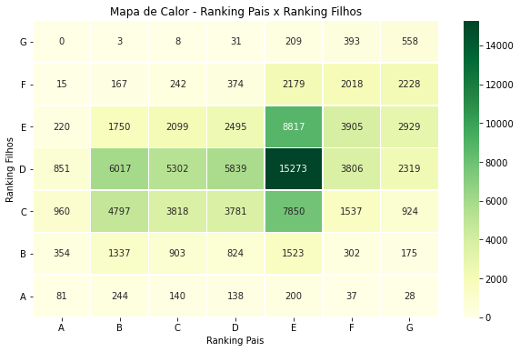

```python
## plot rank - rank
fig = plt.figure(figsize=(10,6))
ax = sea.heatmap(pd.crosstab(df_clusters['ranking_nota_enem_sg_uf_residencia'],
                        df_clusters['ranking_pais']),
            annot=True,
            fmt="d",
            linewidths=.5,
            cmap="YlGn")
ax.invert_yaxis()
ax.set(xlabel='Ranking Pais', ylabel='Ranking Filhos')
plt.yticks(rotation=0)
#plt.legend(labels=['Ranking Pais','Ranking Filhos'])
plt.title("Mapa de Calor - Ranking Pais x Ranking Filhos")
plt.show()
```

```python
## trecho para criar dataframe responsável por exibir histogramas

df_densidade = pd.DataFrame()
df_densidade['nota'] = df['nota_enem']


# homem / mulher
df_densidade['homem'] = (df[df['feminino'] == 0])['nota_enem']
df_densidade['mulher']= (df[df['feminino'] != 0])['nota_enem']


# publico / privada
df_densidade['publico']= (df[df['publico'] == 1])['nota_enem']
df_densidade['privada']= (df[df['privada'] == 1])['nota_enem']


# pretos / brancos
df_densidade['pretos']= (df[df['preto'] == 1])['nota_enem']
df_densidade['brancos']= (df[df['branco'] == 1])['nota_enem']


# pais educados / pais não educados.
# obs1. pais com ensino fundamental 2 completo serão considerados educados
# obs2. se ao menos um dos dois forem educados os pais serão considerados educados.
v_educ = ['D','E','F','G'] ## >= Ensino Fundamental 2
v_n_educ = ['A','B','C' ] ## < Ensino Fundamental 2

# se ao menos um dos dois pais forem educados (D,E,F e G), então o aluno é considerado com pais educados
df_densidade['pais_educ']= df.loc[df.educ_pai.isin(v_educ) | df.educ_mae.isin(v_educ)]['nota_enem']
df_densidade['pais_n_educ']= df.loc[df.educ_pai.isin(v_n_educ) & df.educ_mae.isin(v_n_educ)]['nota_enem']
```

## Homem e Mulher:

A média das notas dos homens (527.7 pontos) foi um pouco superior à média das participantes do sexo feminino (515.5 pontos). A dispersão das notas em torno da média foi um pouco maior para os homens, apesar de o número de participantes mulheres ter sido maior em nossa amostra. Além disso, como pode-se notar pela Função de Densidade de Probabilidade abaixo, a probabilidade de um homem ter tirado uma nota superior que a média da amostra é maior em relação às mulheres.

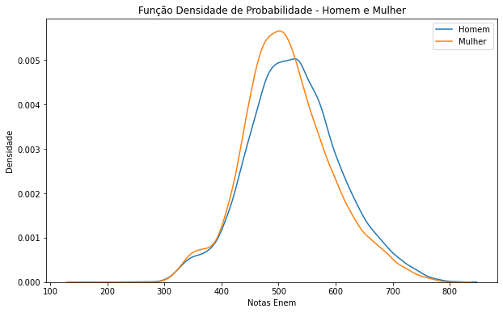

```python
fig = plt.figure(figsize=(10,6))
sea.kdeplot(df_densidade.homem.dropna());
ax = sea.kdeplot(df_densidade.mulher.dropna());
ax.set(xlabel='Notas Enem', ylabel='Densidade')
plt.legend(labels=['Homem','Mulher'])
plt.title("Função Densidade de Probabilidade - Homem e Mulher")
plt.show()
```

## Escolas Públicas e Privadas

A média das notas de participante de escolas públicas (490 pontos) foi superior à das escolas privadas (466 pontos), o que gera num primeiro momento estranheza. A explicação para esse fato é que o número de participantes que declararam ser de escola pública em nossa amostra é de apenas 133 contra 2293 das escolas particulares, ou seja, trata-se de uma quantidade não representativa.

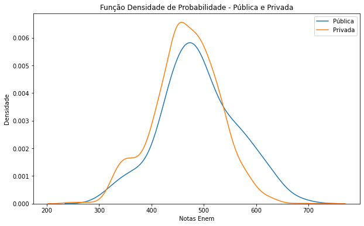

```python
# dados da rede publica não são representativos [apenas 133 de 100k]

fig = plt.figure(figsize=(10,6))
sea.kdeplot(df_densidade.publico.dropna());
ax = sea.kdeplot(df_densidade.privada.dropna());
ax.set(xlabel='Notas Enem', ylabel='Densidade')
plt.legend(labels=['Pública','Privada'])
plt.title("Função Densidade de Probabilidade - Pública e Privada")
plt.show()
```

## Pretos e Brancos

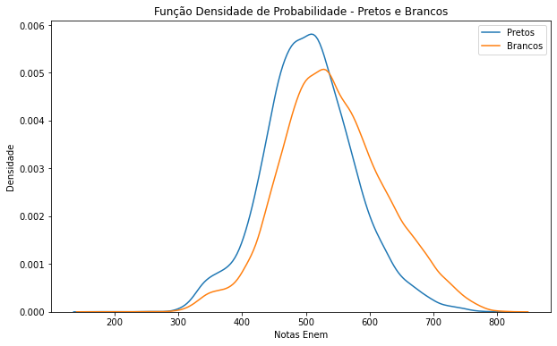

```python
fig = plt.figure(figsize=(10,6))
sea.kdeplot(df_densidade.pretos.dropna());
ax = sea.kdeplot(df_densidade.brancos.dropna());
ax.set(xlabel='Notas Enem', ylabel='Densidade')
plt.legend(labels=['Pretos','Brancos'])
plt.title("Função Densidade de Probabilidade - Pretos e Brancos")
plt.show()
```

## Pais Educados e Pais Não Educados:

Seguindo nossas definições, nossa amostra possui em torno de 70 mil participantes cujo seus pais são escolarizados (Educados). Verificamos que a média e o desvio padrão dos participantes com pais educados é superior aos de pais não educados, sinalizando um possível efeito da escolaridade do pai sobre o desempenho do Filho.

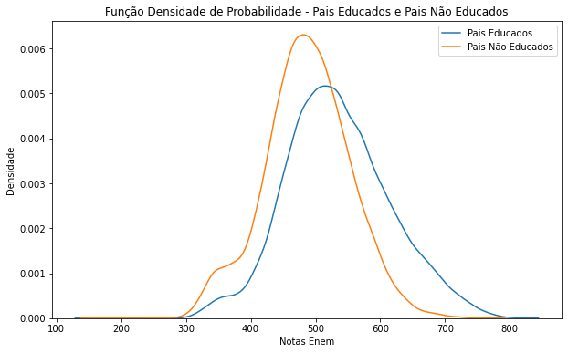

```python
fig = plt.figure(figsize=(10,6))
sea.kdeplot(df_densidade.pais_educ.dropna());
ax = sea.kdeplot(df_densidade.pais_n_educ.dropna());
ax.set(xlabel='Notas Enem', ylabel='Densidade')
plt.legend(labels=['Pais Educados','Pais Não Educados'])
plt.title("Função Densidade de Probabilidade - Pais Educados e Pais Não Educados")
plt.show()
```

# Resultados

Nesta seção realizaremos a análise dos modelos estimados para medir o impacto da educação parental em relação ao desempenho do aluno no exame do Enem. Partindo do modelo inicial de regressão linear Rank-Rank definido por:

$$r_{i,j} = \alpha + \beta RP_i + e_{i,j}$$

Sendo $r_{i,j}$ é o ranking do aluno $i$ em seu estado $j$, $RP$ é o ranking do aluno $i$, $e_{i,j}$ é o erro. As estimativas $\alpha$ e $\beta$ indicarão o valor médio do ranking de cada aluno, independente do ranking dos pais, e o impacto da escolaridade dos pais nas notas dos exames dos filhos, respectivamente.

## Modelo Rank-Rank

Ambas estimativas resultantes são significantes a 1% (P < 0,01). O Intercepto $\alpha$, indica a posição do ranking do participante independentemente da posição do ranking dos pais. Dessa forma, o desempenho médio dos participantes, sem levarmos em consideração o ranking dos pais, os colocam no nível "C". O coeficiente $\beta$, nos diz que em média, a variação de uma unidade de ranking dos pais, faz com que os participantes aumentem 0,2405 unidades de ranking na nota do Enem.

```python
# variáveis utilizadas para regressão
variables = ['sq_ranking_'+str(grade_column) + '_' + group_column, 'sq_ranking_pais']

# define variável dependente
y = 'sq_ranking_'+str(grade_column) + '_' + group_column

# demais serão explicativas
x = [var for var in variables if var not in y ]

# cria dataframe apenas com colunas necessárias
df_ols = df_clusters[variables]

# modelo y = alfa + beta
model = stat.OLS(df_ols[y], add_constant(df_ols[x].astype(float))).fit()
```

```python
if type_exec == 'Latex':
#    Latex(('\\begin{center}'))
        res_print = Latex((model.summary().as_latex()))
#    Latex(('\end{center}'))
else:
    res_print = model.summary()
res_print
```

OLS Regression Results

| Dep. Variable: | sq_ranking_nota_enem_sg_uf_residencia | R-squared: | 0.123 |
| --- | --- | --- | --- |
| Model: | OLS | Adj. R-squared: | 0.122 |
| Method: | Least Squares | F-statistic: | 1.396e+04 |
| Date: | Fri, 05 Feb 2021 | Prob (F-statistic): | 0.00 |
| Time: | 11:51:33 | Log-Likelihood: | -1.4234e+05 |
| No. Observations: | 100000 | AIC: | 2.847e+05 |
| Df Residuals: | 99998 | BIC: | 2.847e+05 |
| Df Model: | 1 |  |  |
| Covariance Type: | nonrobust |  |  |

|  | coef | std err | t | P>\|t\| | [0.025 | 0.975] |
| --- | --- | --- | --- | --- | --- | --- |
| const | 2.9757 | 0.009 | 313.764 | 0.000 | 2.957 | 2.994 |
| sq_ranking_pais | 0.2405 | 0.002 | 118.153 | 0.000 | 0.237 | 0.245 |

| Omnibus: | 126.067 | Durbin-Watson: | 2.002 |
| --- | --- | --- | --- |
| Prob(Omnibus): | 0.000 | Jarque-Bera (JB): | 129.347 |
| Skew: | -0.075 | Prob(JB): | 8.18e-29 |
| Kurtosis: | 3.094 | Cond. No. | 14.5 |

Notes:  
[1] Standard Errors assume that the covariance matrix of the errors is correctly specified.

## Modelo Rank-Rank sub-amostras

```python
# filtro escolas privadas / publicas
df_clusters_privada = df_clusters[df_clusters['privada'] == 1]
df_clusters_publica = df_clusters[df_clusters['publico'] == 1]

# filtro mulher / homem
df_clusters_mulheres = df_clusters[df_clusters['feminino'] == 1]
df_clusters_homens = df_clusters[df_clusters['feminino'] != 1]

# filtro pretos / brancos
df_clusters_pretos = df_clusters[df_clusters['preto'] == 1]
df_clusters_brancos = df_clusters[df_clusters['branco'] == 1]

# cria dataframe apenas com colunas necessárias
df_ols_privada = df_clusters_privada[variables]
df_ols_publica = df_clusters_publica[variables]

df_ols_mulheres = df_clusters_mulheres[variables]
df_ols_homens = df_clusters_homens[variables]

df_ols_pretos = df_clusters_pretos[variables]
df_ols_brancos = df_clusters_brancos[variables]

# modelo y = alfa + beta
model_privada = stat.OLS(df_ols_privada[y], add_constant(df_ols_privada[x].astype(float))).fit()
model_publica = stat.OLS(df_ols_publica[y], add_constant(df_ols_publica[x].astype(float))).fit()

model_mulheres = stat.OLS(df_ols_mulheres[y], add_constant(df_ols_mulheres[x].astype(float))).fit()
model_homens = stat.OLS(df_ols_homens[y], add_constant(df_ols_homens[x].astype(float))).fit()

model_pretos = stat.OLS(df_ols_pretos[y], add_constant(df_ols_pretos[x].astype(float))).fit()
model_brancos = stat.OLS(df_ols_brancos[y], add_constant(df_ols_brancos[x].astype(float))).fit()
```

### Escolas Públicas vs Escolas Privadas (ensino médio)

Como mencionado anteriormente, a análise entre as escolas do ensino público e privado fica comprometida devido ao baixo número de elementos na amostra, o que pode acarretar em viés. A escola pública contou com 133 observações o coeficiente beta registrou um valor de 0.2208 com um desvio-padrão de 0.056 e olhando para o teste ‘t’, os coeficientes são estatisticamente significativos. Nesse caso, poderíamos inferir que o aumento de um rank da escolaridade do pai influencia 0.22 de aumento no ranking da nota do filho. No caso das escolas privadas o número de observações total foi de 2293, onde o coeficiente beta registrou um valor de 0.1052 e desvio-padrão de 0.013. Da mesma forma, os coeficientes foram estatisticamente significativos no teste ‘t’. Pode-se inferir que entre as escolas privadas o peso no aumento da escolaridade é menor de tal forma que, o incremento de um rank na escolaridade do pai, influencia apenas 0.10 no rankeamento de sua nota no ENEM.

```python
if type_exec == 'Latex':
    res_print = Latex(model_privada.summary().as_latex())
else:
    res_print = (model_privada.summary())
res_print
```

OLS Regression Results

| Dep. Variable: | sq_ranking_nota_enem_sg_uf_residencia | R-squared: | 0.030 |
| --- | --- | --- | --- |
| Model: | OLS | Adj. R-squared: | 0.029 |
| Method: | Least Squares | F-statistic: | 70.67 |
| Date: | Fri, 05 Feb 2021 | Prob (F-statistic): | 7.33e-17 |
| Time: | 11:51:33 | Log-Likelihood: | -3028.1 |
| No. Observations: | 2293 | AIC: | 6060. |
| Df Residuals: | 2291 | BIC: | 6072. |
| Df Model: | 1 |  |  |
| Covariance Type: | nonrobust |  |  |

|  | coef | std err | t | P>\|t\| | [0.025 | 0.975] |
| --- | --- | --- | --- | --- | --- | --- |
| const | 2.9327 | 0.052 | 56.201 | 0.000 | 2.830 | 3.035 |
| sq_ranking_pais | 0.1052 | 0.013 | 8.406 | 0.000 | 0.081 | 0.130 |

| Omnibus: | 28.214 | Durbin-Watson: | 1.982 |
| --- | --- | --- | --- |
| Prob(Omnibus): | 0.000 | Jarque-Bera (JB): | 29.092 |
| Skew: | -0.276 | Prob(JB): | 4.82e-07 |
| Kurtosis: | 2.976 | Cond. No. | 12.1 |

Notes:  
[1] Standard Errors assume that the covariance matrix of the errors is correctly specified.

```python
if type_exec == 'Latex':
    res_print = Latex((model_publica.summary().as_latex()))
else:
    res_print = model_publica.summary()
res_print
```

OLS Regression Results

| Dep. Variable: | sq_ranking_nota_enem_sg_uf_residencia | R-squared: | 0.107 |
| --- | --- | --- | --- |
| Model: | OLS | Adj. R-squared: | 0.100 |
| Method: | Least Squares | F-statistic: | 15.65 |
| Date: | Fri, 05 Feb 2021 | Prob (F-statistic): | 0.000124 |
| Time: | 11:51:33 | Log-Likelihood: | -179.05 |
| No. Observations: | 133 | AIC: | 362.1 |
| Df Residuals: | 131 | BIC: | 367.9 |
| Df Model: | 1 |  |  |
| Covariance Type: | nonrobust |  |  |

|  | coef | std err | t | P>\|t\| | [0.025 | 0.975] |
| --- | --- | --- | --- | --- | --- | --- |
| const | 2.7264 | 0.255 | 10.674 | 0.000 | 2.221 | 3.232 |
| sq_ranking_pais | 0.2208 | 0.056 | 3.955 | 0.000 | 0.110 | 0.331 |

| Omnibus: | 0.867 | Durbin-Watson: | 2.063 |
| --- | --- | --- | --- |
| Prob(Omnibus): | 0.648 | Jarque-Bera (JB): | 0.886 |
| Skew: | -0.009 | Prob(JB): | 0.642 |
| Kurtosis: | 2.601 | Cond. No. | 15.0 |

Notes:  
[1] Standard Errors assume that the covariance matrix of the errors is correctly specified.

### Estudantes homens vs mulheres

Os dois grupos apresentaram coeficientes estatisticamente significativos e com desvios-padrão relativamente pequenos, iguais, no caso do beta. Os dados sugerem que, para um maior ranqueamento da nota do ENEM, a educação dos pais importa mais para as mulheres do que para os homens. No caso, o coeficiente beta que explica essa relação, registrou valores de 0.2482 e 0.2243 para mulheres e homens, respectivamente.

```python
if type_exec == 'Latex':
    res_print = Latex((model_mulheres.summary().as_latex()))
else:
    res_print = (model_mulheres.summary())
res_print
```

OLS Regression Results

| Dep. Variable: | sq_ranking_nota_enem_sg_uf_residencia | R-squared: | 0.138 |
| --- | --- | --- | --- |
| Model: | OLS | Adj. R-squared: | 0.138 |
| Method: | Least Squares | F-statistic: | 9266. |
| Date: | Fri, 05 Feb 2021 | Prob (F-statistic): | 0.00 |
| Time: | 11:51:33 | Log-Likelihood: | -81215. |
| No. Observations: | 58100 | AIC: | 1.624e+05 |
| Df Residuals: | 58098 | BIC: | 1.625e+05 |
| Df Model: | 1 |  |  |
| Covariance Type: | nonrobust |  |  |

|  | coef | std err | t | P>\|t\| | [0.025 | 0.975] |
| --- | --- | --- | --- | --- | --- | --- |
| const | 2.9064 | 0.012 | 246.451 | 0.000 | 2.883 | 2.929 |
| sq_ranking_pais | 0.2482 | 0.003 | 96.258 | 0.000 | 0.243 | 0.253 |

| Omnibus: | 68.101 | Durbin-Watson: | 2.004 |
| --- | --- | --- | --- |
| Prob(Omnibus): | 0.000 | Jarque-Bera (JB): | 71.593 |
| Skew: | -0.063 | Prob(JB): | 2.84e-16 |
| Kurtosis: | 3.118 | Cond. No. | 13.8 |

Notes:  
[1] Standard Errors assume that the covariance matrix of the errors is correctly specified.

```python
if type_exec == 'Latex':
    res_print = Latex(model_homens.summary().as_latex())
else:
    res_print = (model_homens.summary())
res_print
```

OLS Regression Results

| Dep. Variable: | sq_ranking_nota_enem_sg_uf_residencia | R-squared: | 0.099 |
| --- | --- | --- | --- |
| Model: | OLS | Adj. R-squared: | 0.099 |
| Method: | Least Squares | F-statistic: | 4591. |
| Date: | Fri, 05 Feb 2021 | Prob (F-statistic): | 0.00 |
| Time: | 11:51:33 | Log-Likelihood: | -60936. |
| No. Observations: | 41900 | AIC: | 1.219e+05 |
| Df Residuals: | 41898 | BIC: | 1.219e+05 |
| Df Model: | 1 |  |  |
| Covariance Type: | nonrobust |  |  |

|  | coef | std err | t | P>\|t\| | [0.025 | 0.975] |
| --- | --- | --- | --- | --- | --- | --- |
| const | 3.0998 | 0.016 | 196.145 | 0.000 | 3.069 | 3.131 |
| sq_ranking_pais | 0.2243 | 0.003 | 67.754 | 0.000 | 0.218 | 0.231 |

| Omnibus: | 79.394 | Durbin-Watson: | 1.988 |
| --- | --- | --- | --- |
| Prob(Omnibus): | 0.000 | Jarque-Bera (JB): | 79.980 |
| Skew: | -0.103 | Prob(JB): | 4.29e-18 |
| Kurtosis: | 3.057 | Cond. No. | 15.5 |

Notes:  
[1] Standard Errors assume that the covariance matrix of the errors is correctly specified.

### Estudantes Pretos vs Brancos

Entre os estudantes que se autodeclararam pretos ou brancos, os coeficientes também foram estatisticamente significativos quando observamos os testes estatísticos. Entre aqueles que se autodeclararam pretos, o coeficiente beta atingiu 0.1741, enquanto que os que se autodeclararam brancos chegou a 0.2748, ou seja, uma escolaridade maior dos pais, tem um peso maior na nota do ENEM entre os indivíduos que se autodeclararam brancos, pode existir o fator renda que influencie isso. Os desvios-padrão foram relativamente pequenos nos dois grupos.

```python
if type_exec == 'Latex':
    res_print = Latex(model_pretos.summary().as_latex())
else:
    res_print = (model_pretos.summary())
res_print
```

OLS Regression Results

| Dep. Variable: | sq_ranking_nota_enem_sg_uf_residencia | R-squared: | 0.072 |
| --- | --- | --- | --- |
| Model: | OLS | Adj. R-squared: | 0.072 |
| Method: | Least Squares | F-statistic: | 1002. |
| Date: | Fri, 05 Feb 2021 | Prob (F-statistic): | 8.05e-212 |
| Time: | 11:51:33 | Log-Likelihood: | -17830. |
| No. Observations: | 12965 | AIC: | 3.566e+04 |
| Df Residuals: | 12963 | BIC: | 3.568e+04 |
| Df Model: | 1 |  |  |
| Covariance Type: | nonrobust |  |  |

|  | coef | std err | t | P>\|t\| | [0.025 | 0.975] |
| --- | --- | --- | --- | --- | --- | --- |
| const | 3.1770 | 0.024 | 132.112 | 0.000 | 3.130 | 3.224 |
| sq_ranking_pais | 0.1741 | 0.006 | 31.649 | 0.000 | 0.163 | 0.185 |

| Omnibus: | 41.700 | Durbin-Watson: | 1.949 |
| --- | --- | --- | --- |
| Prob(Omnibus): | 0.000 | Jarque-Bera (JB): | 46.677 |
| Skew: | -0.094 | Prob(JB): | 7.32e-11 |
| Kurtosis: | 3.226 | Cond. No. | 13.1 |

Notes:  
[1] Standard Errors assume that the covariance matrix of the errors is correctly specified.

```python
if type_exec == 'Latex':
    res_print = Latex((model_brancos.summary().as_latex()))
else:
    res_print = (model_brancos.summary())
res_print
```

OLS Regression Results

| Dep. Variable: | sq_ranking_nota_enem_sg_uf_residencia | R-squared: | 0.143 |
| --- | --- | --- | --- |
| Model: | OLS | Adj. R-squared: | 0.143 |
| Method: | Least Squares | F-statistic: | 5986. |
| Date: | Fri, 05 Feb 2021 | Prob (F-statistic): | 0.00 |
| Time: | 11:51:33 | Log-Likelihood: | -51559. |
| No. Observations: | 35957 | AIC: | 1.031e+05 |
| Df Residuals: | 35955 | BIC: | 1.031e+05 |
| Df Model: | 1 |  |  |
| Covariance Type: | nonrobust |  |  |

|  | coef | std err | t | P>\|t\| | [0.025 | 0.975] |
| --- | --- | --- | --- | --- | --- | --- |
| const | 2.9707 | 0.018 | 167.004 | 0.000 | 2.936 | 3.006 |
| sq_ranking_pais | 0.2748 | 0.004 | 77.366 | 0.000 | 0.268 | 0.282 |

| Omnibus: | 80.685 | Durbin-Watson: | 2.001 |
| --- | --- | --- | --- |
| Prob(Omnibus): | 0.000 | Jarque-Bera (JB): | 81.172 |
| Skew: | -0.115 | Prob(JB): | 2.36e-18 |
| Kurtosis: | 3.030 | Cond. No. | 17.2 |

Notes:  
[1] Standard Errors assume that the covariance matrix of the errors is correctly specified.

## Modelo Rank-Rank incluindo a Renda

Incluídas as variáveis de idade e renda no modelo, verificou-se uma queda acentuada no peso do ranking de educação dos pais para 0.1237, ante 0.2405 do modelo anterior. Apesar de exprimir uma relação negativa com a nota do ENEM, a idade tem peso irrelevante no ranqueamento da nota já que apresentou um coeficiente de -0.0053. Em contrapartida a renda apresentou uma relação positiva de 0.1150 com o ranqueamento da nota, ou seja, que o aumento da na faixa de renda, influencia em um aumento no ranking da nota do ENEM. A título de conhecimento, quando se elimina a idade do modelo, o ranking de educação e renda passam a ter coeficientes de 0.1325 e 0.1142, respectivamente. Com os coeficientes estatisticamente significativos. Claramente, pais mais educados e com maiores rendas influenciam positivamente na nota do filho.

```python
# variáveis utilizadas para regressão
variables = ['sq_ranking_'+str(grade_column) + '_' + group_column,
             'sq_ranking_pais',
             'idade',
             'sq_renda'
            ]

# define variável dependente
y = 'sq_ranking_'+str(grade_column) + '_' + group_column

# demais serão explicativas
x = [var for var in variables if var not in y ]

# cria dataframe apenas com colunas necessárias

df_ols = df_clusters[variables]
df_ols = df_ols.dropna() # removendo linhas NaN

# modelo y = alfa + beta
model_idade_renda = stat.OLS(df_ols[y], add_constant(df_ols[x].astype(float))).fit()

# idade é significante (menos que as demais) e é um fator redutor.
# renda é significante e é um fator com correlação positiva.
if type_exec == 'Latex':
    res_print = Latex(model_idade_renda.summary().as_latex())
else:
    res_print = (model_idade_renda.summary())
res_print
```

OLS Regression Results

| Dep. Variable: | sq_ranking_nota_enem_sg_uf_residencia | R-squared: | 0.216 |
| --- | --- | --- | --- |
| Model: | OLS | Adj. R-squared: | 0.216 |
| Method: | Least Squares | F-statistic: | 9207. |
| Date: | Fri, 05 Feb 2021 | Prob (F-statistic): | 0.00 |
| Time: | 11:51:34 | Log-Likelihood: | -1.3667e+05 |
| No. Observations: | 99998 | AIC: | 2.733e+05 |
| Df Residuals: | 99994 | BIC: | 2.734e+05 |
| Df Model: | 3 |  |  |
| Covariance Type: | nonrobust |  |  |

|  | coef | std err | t | P>\|t\| | [0.025 | 0.975] |
| --- | --- | --- | --- | --- | --- | --- |
| const | 3.0834 | 0.016 | 198.793 | 0.000 | 3.053 | 3.114 |
| sq_ranking_pais | 0.1237 | 0.002 | 54.217 | 0.000 | 0.119 | 0.128 |
| idade | -0.0053 | 0.000 | -12.165 | 0.000 | -0.006 | -0.004 |
| sq_renda | 0.1150 | 0.001 | 109.371 | 0.000 | 0.113 | 0.117 |

| Omnibus: | 498.838 | Durbin-Watson: | 2.007 |
| --- | --- | --- | --- |
| Prob(Omnibus): | 0.000 | Jarque-Bera (JB): | 530.655 |
| Skew: | -0.148 | Prob(JB): | 5.89e-116 |
| Kurtosis: | 3.199 | Cond. No. | 126. |

Notes:  
[1] Standard Errors assume that the covariance matrix of the errors is correctly specified.

```python
# variáveis utilizadas para regressão
variables = ['sq_ranking_'+str(grade_column) + '_' + group_column,
             'sq_ranking_pais',
             'sq_renda'
            ]

# define variável dependente
y = 'sq_ranking_'+str(grade_column) + '_' + group_column

# demais serão explicativas
x = [var for var in variables if var not in y ]

# cria dataframe apenas com colunas necessárias
df_ols = df_clusters[variables]

# modelo y = alfa + beta
model_renda = stat.OLS(df_ols[y], add_constant(df_ols[x].astype(float))).fit()

## como likelihood mudou muito pouco,
# apesar da idade ser significante não acredito que ela deva entrar na equação
# TODO: Fazer a conta
```

```python
if type_exec == 'Latex':
    res_print = Latex(model_renda.summary().as_latex())
else:
    res_print = (model_renda.summary())
res_print
```

OLS Regression Results

| Dep. Variable: | sq_ranking_nota_enem_sg_uf_residencia | R-squared: | 0.215 |
| --- | --- | --- | --- |
| Model: | OLS | Adj. R-squared: | 0.215 |
| Method: | Least Squares | F-statistic: | 1.372e+04 |
| Date: | Fri, 05 Feb 2021 | Prob (F-statistic): | 0.00 |
| Time: | 11:51:34 | Log-Likelihood: | -1.3675e+05 |
| No. Observations: | 100000 | AIC: | 2.735e+05 |
| Df Residuals: | 99997 | BIC: | 2.735e+05 |
| Df Model: | 2 |  |  |
| Covariance Type: | nonrobust |  |  |

|  | coef | std err | t | P>\|t\| | [0.025 | 0.975] |
| --- | --- | --- | --- | --- | --- | --- |
| const | 2.9295 | 0.009 | 326.277 | 0.000 | 2.912 | 2.947 |
| sq_ranking_pais | 0.1325 | 0.002 | 61.169 | 0.000 | 0.128 | 0.137 |
| sq_renda | 0.1142 | 0.001 | 108.753 | 0.000 | 0.112 | 0.116 |

| Omnibus: | 508.968 | Durbin-Watson: | 2.007 |
| --- | --- | --- | --- |
| Prob(Omnibus): | 0.000 | Jarque-Bera (JB): | 544.156 |
| Skew: | -0.148 | Prob(JB): | 6.89e-119 |
| Kurtosis: | 3.207 | Cond. No. | 21.6 |

Notes:  
[1] Standard Errors assume that the covariance matrix of the errors is correctly specified.

## Estimativa para o Brasil

Considerando que quanto maior for o valor de $\beta$, menor será a mobilidade intergeracional educacional, a estimação dos coeficientes para os estados não revelou padrões significativos que possibilitam a correta inferência com base em características locais conhecidas pelos autores. Imagina-se que um conjunto de fatores são decisivos para as diferenças, levando em conta desigualdade, renda, custo de vida, entre outros indicadores sociais relevantes. Curiosamente, o estado de Roraima apresenta alto valor no coeficiente beta, sugerindo que em condições muito escassas de oportunidade, favorece a baixa mobilidade. Contudo os demais estados da região Norte apresentaram coeficientes menores, sugerindo uma alta mobilidade na Região, ou seja, pouco interfere o quão educado são os pais no desempenho do aluno no exame do Enem.

```python
# estimar vetor de betas dos estados
variables = ['sq_ranking_'+str(grade_column) + '_' + group_column,
             'sq_ranking_pais']

# define variável dependente
y = 'sq_ranking_'+str(grade_column) + '_' + group_column

# demais serão explicativas
x = [var for var in variables if var not in y ]

ufs = df['sg_uf_residencia'].unique()

uf_regressions = []
for uf in ufs:
    # cria dataframe apenas com colunas necessárias
    df_ols_uf = df_clusters[df_clusters['sg_uf_residencia'] == uf][variables]
    # modelo y = alfa + beta
    model_uf = stat.OLS(df_ols_uf[y], add_constant(df_ols_uf[x].astype(float))).fit()
    #print(model_uf.summary())
    #print(model_uf.params)
    #break
    alfa = None
    beta = None
    if len(model_uf.params) > 0:
        alfa = model_uf.params[0]
    if len(model_uf.params) > 1:
        beta = model_uf.params[1]
        pvalue = model_uf.pvalues[1]
    row = [uf, alfa, beta, pvalue]
    uf_regressions.append(row)
#uf_regressions
```

```python
# Prepara os dados


# carrega arquivo de mapas (fonte IBGE)
fp = 'br_unidades_da_federacao//BR_UF_2019.shp'
# transforma dados shpfile para dataframe
map_df = gpd.read_file(fp)
# transforma tabela de alfas / betas em dataframe
df_uf_regressions = pd.DataFrame(uf_regressions,
                                 columns=['sigla_uf',
                                          'alfa',
                                          'beta', 'pvalue'])

# faz o join entre os dois dataframes
merged = map_df.set_index('SIGLA_UF').join(df_uf_regressions.set_index('sigla_uf'))
```

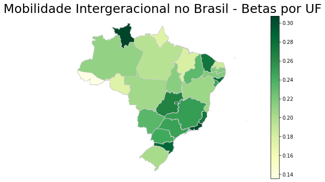

```python
# Gera heat map

# set a variable that will call whatever column we want to visualise on the map
variable = 'beta'
# set the range for the choropleth
vmin, vmax = min(df_uf_regressions.beta), max(df_uf_regressions.beta)
# create figure and axes for Matplotlib
fig, ax = plt.subplots(1, figsize=(10, 6))
merged.plot(column=variable, cmap='YlGn', linewidth=0.8, ax=ax, edgecolor='0.8')
# remove the axis
ax.axis('off')
# add a title
ax.set_title('Mobilidade Intergeracional no Brasil - Betas por UF', fontdict={'fontsize': '25', 'fontweight' : '3'})
# create an annotation for the data source
#ax.annotate('fonte: regressão linear',xy=(0.1, .08), xycoords='figure fraction', horizontalalignment='left', verticalalignment='top', fontsize=12, color='#555555')
# Create colorbar as a legend
sm = plt.cm.ScalarMappable(cmap='YlGn', norm=plt.Normalize(vmin=vmin, vmax=vmax))
# empty array for the data range
sm._A = []
# add the colorbar to the figure
cbar = fig.colorbar(sm)
#saving our map as .png file.
fig.savefig('map_export.png', dpi=300)
```

```python
# estimar vetor de betas dos estados
variables = ['sq_ranking_'+ str(grade_column) + '_' + group_column,
             'sq_ranking_pais']

# define variável dependente
y = 'sq_ranking_'+str(grade_column) + '_' + group_column

# demais serão explicativas
x = [var for var in variables if var not in y ]

municipios = df['co_municipio_residencia'].unique()

mun_regressions = []
for mun in municipios:
    # cria dataframe apenas com colunas necessárias
    df_ols_mun = df_clusters[df_clusters['co_municipio_residencia'] == mun][variables]
    # modelo y = alfa + beta
    model_mun = stat.OLS(df_ols_mun[y], add_constant(df_ols_mun[x].astype(float))).fit()
    #print(model_uf.summary())
    #print(model_uf.params)
    #break
    alfa = None
    beta = None
    if len(model_mun.params) > 0:
        alfa = model_mun.params[0]
    if len(model_mun.params) > 1:
        beta = model_mun.params[1]
        pvalue = model_mun.pvalues[1]
    row = [mun, alfa, beta, pvalue]
    mun_regressions.append(row)
#uf_regressions
```

```python
# Prepara os dados


# carrega arquivo de mapas (fonte IBGE)
fp = 'br_municipios_20200807//BR_Municipios_2019.shp'
# transforma dados shpfile para dataframe
map_df_mun = gpd.read_file(fp)
# transforma tabela de alfas / betas em dataframe
df_mun_regressions = pd.DataFrame(mun_regressions,
                                 columns=['CD_MUN',
                                          'ALFA',
                                          'BETA', 'pvalue'],)

df_mun_regressions.CD_MUN = df_mun_regressions.CD_MUN.astype(str)

#map_df.head()
# faz o join entre os dois dataframes
merged_mun = map_df_mun.set_index('CD_MUN').join(df_mun_regressions.set_index('CD_MUN'))
#df_uf_regressions.head()
```

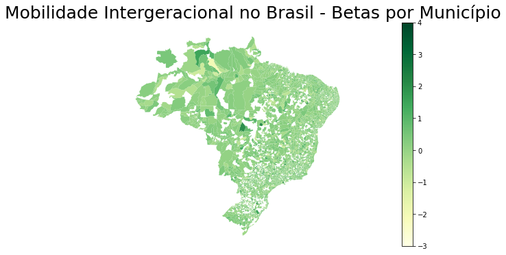

```python
# Gera heat map

# set a variable that will call whatever column we want to visualise on the map
variable = 'BETA'
# set the range for the choropleth
vmin, vmax = min(df_mun_regressions.BETA), max(df_mun_regressions.BETA)
# create figure and axes for Matplotlib
fig, ax = plt.subplots(1, figsize=(10, 6))
merged_mun.plot(column=variable, cmap='YlGn', linewidth=0.0, ax=ax, edgecolor='0.0')
# remove the axis
ax.axis('off')
# add a title
ax.set_title('Mobilidade Intergeracional no Brasil - Betas por Município', fontdict={'fontsize': '25', 'fontweight' : '3'})
# create an annotation for the data source
#ax.annotate('fonte: regressão linear',xy=(0.1, .08), xycoords='figure fraction', horizontalalignment='left', verticalalignment='top', fontsize=12, color='#555555')
# Create colorbar as a legend
sm = plt.cm.ScalarMappable(cmap='YlGn', norm=plt.Normalize(vmin=vmin, vmax=vmax))
# empty array for the data range
sm._A = []
# add the colorbar to the figure
cbar = fig.colorbar(sm)
#saving our map as .png file.
fig.savefig('map_mun_export.png', dpi=300)
```

## Estimativa Macroeconômica

```python
df_transf_mun = pd.read_excel('Data//transf_mun_2.xlsx')


df_transf_mun['LOG_TRANSF'] = np.log(df_transf_mun['TRANSF_ALUNO'])
df_transf_mun.COD_IBGE = df_transf_mun.COD_IBGE.astype(str)
df_transf_mun = df_transf_mun[['COD_IBGE','TRANSF_ALUNO','LOG_TRANSF']]
```

```python
df_transf_mun = df_transf_mun.set_index('COD_IBGE').join(df_mun_regressions.set_index('CD_MUN'))
```

```python
#df_transf_mun.CD_MUN = df_transf_mun.COD_IBGE
#merged_mun.head()
if type_exec == 'Latex':
    res_print = Latex((df_transf_mun.head().to_latex()))
else:
    res_print =(df_transf_mun.head())
res_print
```

| COD_IBGE | TRANSF_ALUNO | LOG_TRANSF | ALFA | BETA | pvalue |
| --- | --- | --- | --- | --- | --- |
| 1200013 | 722.549125 | 6.582785 | 2.681004 | 0.304659 | 0.002647 |
| 1200054 | 697.153512 | 6.547006 | 1.500000 | NaN | NaN |
| 1200104 | 881.094827 | 6.781165 | 4.666667 | -0.151515 | 0.716288 |
| 1200138 | 248.630782 | 5.515969 | 2.238095 | 0.261905 | 0.598703 |
| 1200179 | 960.450937 | 6.867403 | 3.441860 | 0.046512 | 0.776959 |

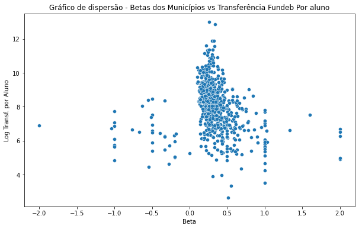

```python
## removendo estimações de beta não significantes:

df_transf_mun_sig = df_transf_mun[df_transf_mun['pvalue'] < 0.05]
fig = plt.figure(figsize=(10,6))

ax = sea.scatterplot(data=df_transf_mun_sig.dropna(), x='BETA', y="LOG_TRANSF")

ax.set(xlabel='Beta', ylabel='Log Transf. por Aluno')
plt.title("Gráfico de dispersão - Betas dos Municípios vs Transferência Fundeb Por aluno")
plt.show()
```

```python
# variáveis utilizadas para regressão
variables = ['BETA','LOG_TRANSF']

# define variável dependente
y = 'BETA'

# demais serão explicativas
x = [var for var in variables if var not in y ]

# cria dataframe apenas com colunas necessárias
df_ols = df_transf_mun_sig[variables]

# modelo y = alfa + beta
model_transf_fundeb = stat.OLS(df_ols[y], add_constant(df_ols[x].astype(float))).fit()

## como likelihood mudou muito pouco,
# apesar da idade ser significante não acredito que ela deva entrar na equação
# TODO: Fazer a conta
```

```python
if type_exec == 'Latex':
    res_print = Latex((model_transf_fundeb.summary().as_latex()))
else:
    res_print = (model_transf_fundeb.summary())
res_print
```

OLS Regression Results

| Dep. Variable: | BETA | R-squared: | nan |
| --- | --- | --- | --- |
| Model: | OLS | Adj. R-squared: | nan |
| Method: | Least Squares | F-statistic: | nan |
| Date: | Fri, 05 Feb 2021 | Prob (F-statistic): | nan |
| Time: | 11:52:21 | Log-Likelihood: | nan |
| No. Observations: | 771 | AIC: | nan |
| Df Residuals: | 771 | BIC: | nan |
| Df Model: | -1 |  |  |
| Covariance Type: | nonrobust |  |  |

|  | coef | std err | t | P>\|t\| | [0.025 | 0.975] |
| --- | --- | --- | --- | --- | --- | --- |
| const | nan | nan | nan | nan | nan | nan |
| LOG_TRANSF | nan | nan | nan | nan | nan | nan |

| Omnibus: | nan | Durbin-Watson: | nan |
| --- | --- | --- | --- |
| Prob(Omnibus): | nan | Jarque-Bera (JB): | nan |
| Skew: | nan | Prob(JB): | nan |
| Kurtosis: | nan | Cond. No. | nan |

Notes:  
[1] Standard Errors assume that the covariance matrix of the errors is correctly specified.

```python
#Estimações não utilizadas


# df_mun_pib = pd.read_excel('Data//pib_municipios.xls')

# df_mun_pib['Código do Município'] = df_mun_pib['Código do Município'].astype(str)

# df_mun_pib = df_mun_pib[['Ano','Código do Município','Produto Interno Bruto per capita, \na preços correntes\n(R$ 1,00)', 'Valor adicionado bruto da Indústria,\na preços correntes\n(R$ 1.000)']]

# df_mun_pib['LOG_PIB'] = np.log(df_mun_pib['Produto Interno Bruto per capita, \na preços correntes\n(R$ 1,00)'])
# df_mun_pib['LOG_PIB_IND'] = np.log(df_mun_pib['Valor adicionado bruto da Indústria,\na preços correntes\n(R$ 1.000)'])
```

```python
# df_mun_pib = df_mun_pib.set_index('Código do Município').join(df_mun_regressions.set_index('CD_MUN'))
```

```python
# df_mun_pib_sig = df_mun_pib[df_mun_pib['pvalue']< 0.05 ]
# sea.scatterplot(data=df_mun_pib_sig[df_mun_pib_sig['Ano']==2010].dropna(), x='BETA', y="LOG_PIB_IND")

# df_mun_pib_sig[df_mun_pib_sig['Ano']==2010].describe()
```

```python
# df_mun_idfm = pd.read_excel('Data//ipeadata_ifdm.xls')

# df_mun_idfm.Codigo = df_mun_idfm.Codigo.astype(str)

# df_mun_idfm = df_mun_idfm.set_index('Codigo').join(df_mun_regressions.set_index('CD_MUN'))
# df_mun_idfm.describe()
```

```python
# sea.scatterplot(data=df_mun_idfm[df_mun_idfm['pvalue'] < 0.05].dropna(), x='BETA', y="2010")
```